# jekyll-jupyter-notebook20240415-1921-74bz07

### 3.2 Mengaplikasikan filter (*Filtering*)

Sama seperti pada proses *trim* kita juga dapat melihat petunjuk penggunaan `filter`:

```python
help(st.filter)
```

```
Help on method filter in module obspy.core.stream:

filter(type, **options) method of obspy.core.stream.Stream instance
    Filter the data of all traces in the Stream.

    :type type: str
    :param type: String that specifies which filter is applied (e.g.
        ``"bandpass"``). See the `Supported Filter`_ section below for
        further details.
    :param options: Necessary keyword arguments for the respective filter
        that will be passed on. (e.g. ``freqmin=1.0``, ``freqmax=20.0`` for
        ``"bandpass"``)

    .. note::

        This operation is performed in place on the actual data arrays. The
        raw data is not accessible anymore afterwards. To keep your
        original data, use :meth:`~obspy.core.stream.Stream.copy` to create
        a copy of your stream object.
        This also makes an entry with information on the applied processing
        in ``stats.processing`` of every trace.

    .. rubric:: _`Supported Filter`

    ``'bandpass'``
        Butterworth-Bandpass (uses :func:`obspy.signal.filter.bandpass`).

    ``'bandstop'``
        Butterworth-Bandstop (uses :func:`obspy.signal.filter.bandstop`).

    ``'lowpass'``
        Butterworth-Lowpass (uses :func:`obspy.signal.filter.lowpass`).

    ``'highpass'``
        Butterworth-Highpass (uses :func:`obspy.signal.filter.highpass`).

    ``'lowpass_cheby_2'``
        Cheby2-Lowpass (uses :func:`obspy.signal.filter.lowpass_cheby_2`).

    ``'lowpass_fir'`` (experimental)
        FIR-Lowpass (uses :func:`obspy.signal.filter.lowpass_fir`).

    ``'remez_fir'`` (experimental)
        Minimax optimal bandpass using Remez algorithm (uses
        :func:`obspy.signal.filter.remez_fir`).

    .. rubric:: Example

    >>> from obspy import read
    >>> st = read()
    >>> st.filter("highpass", freq=1.0)  # doctest: +ELLIPSIS
    <...Stream object at 0x...>
    >>> st.plot()  # doctest: +SKIP

    .. plot::

        from obspy import read
        st = read()
        st.filter("highpass", freq=1.0)
        st.plot()
```

Contoh untuk filter *highpass* dapat dilakukan dengan:

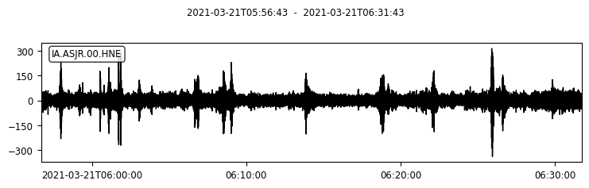

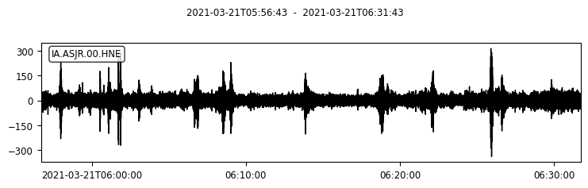

```python
st_filt = st.copy()

st_filt.filter("highpass", freq=2)
st_filt.plot()
```

### 3.3 Melakukan *Resampling*

*Resampling* dapat dilakukan dengan menggunakan fungsi `resample`:

```
1 Trace(s) in Stream:
IA.ASJR.00.HNE | 2021-03-21T05:56:43.000000Z - 2021-03-21T06:31:42.950000Z | 20.0 Hz, 42000 samples
```

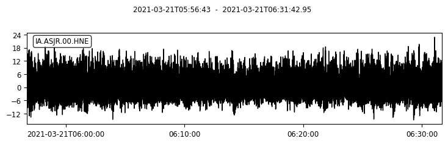

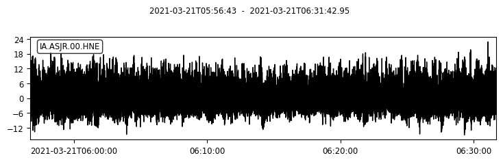

```python
st_resamp = st.copy()
st_resamp.resample(sampling_rate=20)
print(st_resamp)
st_resamp.plot()
```

### 3.4 Menghilangkan *trend*

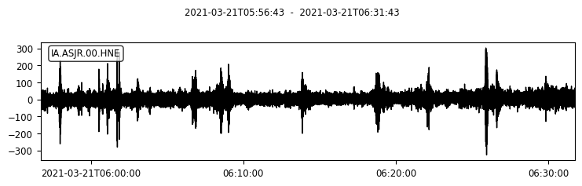

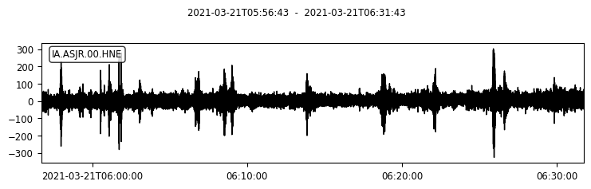

```python
st_detrend = st.copy()
st_detrend.detrend()
st_detrend.plot()
```

### 3.5 Mengeplot spectogram

`obspy` juga memungkinkan pengeplotan spectrogram dengan perintah yang sederhana. Misalkan kita ingin mengeplot spectrogram pada data yang sudah difilter:

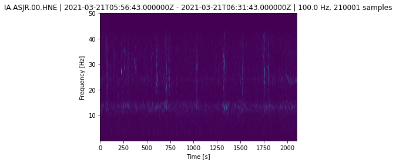

```
[None]
```

```python
st_filt.spectrogram()
```

## 4 Menyimpan Data

Setelah berbagai pengolahan, `obspy` juga memberikan dukungan untuk menyimpan data dengan berbagai format, pada contoh disini data yang sudah difilter akan disimpan ke dalam file menggunakan `Stream.write`:

```python
st_filt.write("data_terfilter.mseed")
```

Data yang sudah disimpan akan masuk di File Explorer Colab dan dapat diunduh.

## 5 Latihan

### 5.1 Membaca data seismik BLJR

```python
st=read('isikan lokasi BLJR Z')
st+=read('isikan lokasi BLJR N')
st+=read('isikan lokasi BLJR E')
print(st)
```

[output not shown]

### 5.2 Mengeplot data seismik BLJR

[figure not shown]

[figure not shown]

```python
# masukkan kode untuk mengeplot
```

### 5.3 Melakukan *Filtering*

```python
# lakukan filter lowpass 5 hz dan plot
```

### 5.4 Menyimpan data

```python
# simpan data ke dalam file dengan write
```